# Spatial Planning Examples

Jason D. Everett (UQ/UNSW/CSIRO)

11/02/2021

This document will contain some examples of Spatial Planning in Prioritiser.

# Generating Planning Units

Load the relevant libraries and source the `fCreate_PlanningUnits.R` file from the Tutorials directory in the [workshop repository](https://github.com/MathMarEcol/SpatialPlanning_Workshop2021).

```r
suppressPackageStartupMessages({
  library(tidyverse)
  library(rnaturalearth)
  library(sf)})

source("fCreate_PlanningUnits.R")
```

First we need to create a polygon of the study site area. This is used as the boundaries of the planning unit generation. The CRS needs to have units of m’s but it is often easier to generate the limits based on degrees, so here we first create the polygon with degrees, and then we convert to a different crs with m’s.

```r
# Create a polygon for the boundary of your study area - The polygon must be continuous from one corner all the way around and back to the same corner.
Bndry <- tibble(x = seq(140, 160, by = 1), y = -20) %>% # Start with N boundary (-20N)
  bind_rows(tibble(x = 160, y = seq(-20, -40, by = -1))) %>% # Then bind to E boundary (160E)
  bind_rows(tibble(x = seq(160, 140, by = -1), y = -40)) %>% # Then S boundary (-40N) - reverse y order
  bind_rows(tibble(x = 140, y = seq(-40, -20, by = 1))) %>% # Then W boundary (140E) - reverse x order
  as.matrix() %>%
  list() %>%
  st_polygon() %>%
  st_sfc(crs = "+proj=longlat +datum=WGS84 +ellps=WGS84 +towgs84=0,0,0") %>% # Current crs
  st_transform(crs = "+proj=utm +zone=56 +south +datum=WGS84 +units=m +no_defs") # Transform crs to m
```

Most study areas will contain land or areas we don’t want to consider. One way to remove these is to provide an `sf` object which has polygons of landmasses, ice shelves or EEZ/ABNJ areas to be excluded. The crs of this object should be the same as the `Bndry`.

```r
# Get a polygon for the landmass from rnaturalearth
LandMass <- ne_countries(country = "Australia", returnclass = "sf", scale = "medium") %>% # Load Landmass
  st_transform(crs = "+proj=utm +zone=56 +south +datum=WGS84 +units=m +no_defs") # Transform crs to m
```

Lets plot the two polygons to ensure they line up ok.

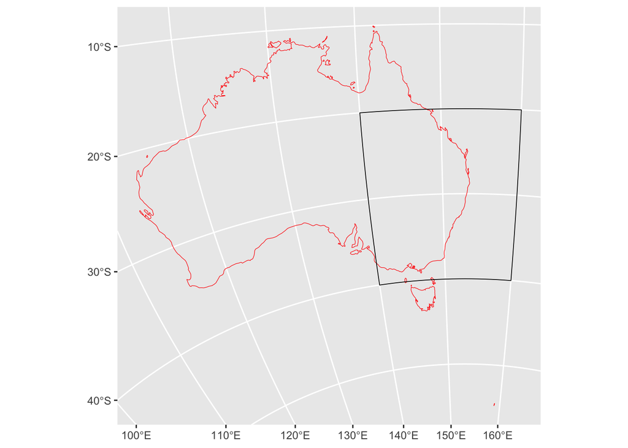

```r
ggplot() +
  geom_sf(data = LandMass, colour = "red", fill = NA, size = 0.2, show.legend = "line") +
  geom_sf(data = Bndry, colour = "black", fill = NA, size = 0.3, show.legend = "line")
```

Now we define the spatial area of the planning units (in kms), and the `Shape` (`Hexagon` or `Square`).

```r
CellArea <- 1000 # kms2
Shape = "Hexagon" # Hexagon or Square
```

This is a function that I wrote which takes all these inputs and returns an sf object containing the PUs with the excluded area.

```r
PUsAus <- fCreate_PlanningUnits(Bndry, LandMass, CellArea, Shape)
```

```
## [1] "Range of cellsize are 1000 km2 to 1000 km2"
```

Now plot it to check the output

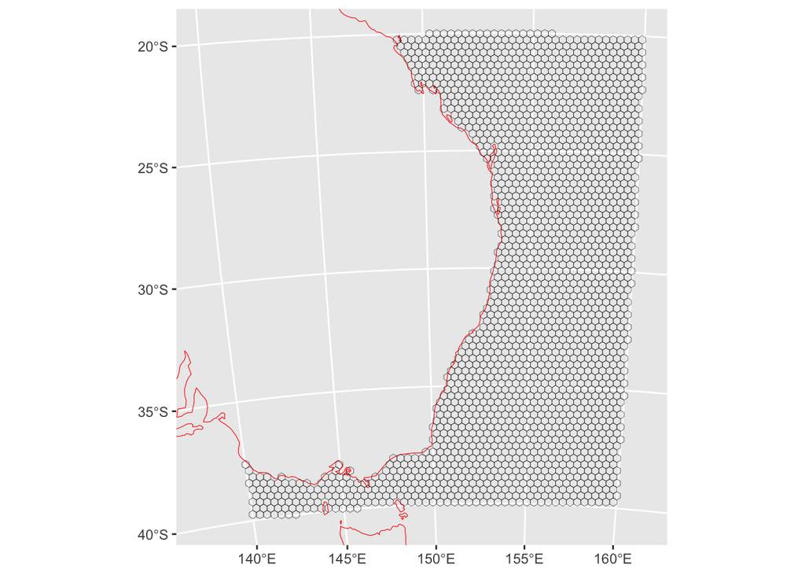

```r
ggplot() +
  geom_sf(data = LandMass, colour = "red", fill = NA, size = 0.2, show.legend = "line") +
  geom_sf(data = PUsAus, colour = "black", fill = NA, size = 0.1, show.legend = "line") +
  coord_sf(xlim = c(st_bbox(Bndry)$xmin, st_bbox(Bndry)$xmax), # Set limits based on Bndry bbox
           ylim = c(st_bbox(Bndry)$ymin, st_bbox(Bndry)$ymax),
           expand = TRUE)
```

If you are happy with the PU’s, you can save them for use later.

```r
st_write(PUsAus, dsn = ".", layer = paste0("PUs_",CellArea,"km2"), driver = "ESRI Shapefile", append = FALSE) #
```

```
## Writing layer `PUs_1000km2' to data source `.' using driver `ESRI Shapefile'
## Writing 1987 features with 0 fields and geometry type Polygon.
```

You can then use `st_read` to load it again.